# Data Analysis Project: Climate Change and Economic Indicators

This notebook analyzes the relationship between CO2 emissions, temperature changes, and economic indicators using multiple datasets.

## Datasets Used:

# Questions 1 - 5

# Motivation

## Why Norway?

After completing the individual project and observing the varying results among different countries in things like CO2 emissions and energy consumption per capita, a key question came to mind regarding how the different practices among countries might correlate to their yearly averages in temperature as well– particularly the country of Norway, whose practices in energy production and other high-intensity sectors are renowned for their sustainability measures.

We thought it would be interesting to look closer at Norway, inspecting any correlation between its own metrics and how it sizes up in comparison to the rest of the world in regards to the variables measured in our selected data.

## Contextual Facts about Norway

[figure not shown]

As can be seen in the figure above, greenhouse gas (GHG) emissions in Norway are largely dominated by CO2 emissions, making up well over 50% of all GHG emissions from the country in 2021.

What is particularly interesting is the fact that, despite being trailblazers in the renewable energy movement in the global community, Norway's GHG emissions in 2021 were driven primarily by the energy sector, as can be seen below. When comparing this figure in isolation to Norway's performance in other sectors, it seems counterintuitive that such sustainable action in the energy sector would result in such emissions.

However, it is key to note that, while Norway's emissions are most heavy in the energy sector, those emissions are relatively manageable when accounting for the offset that their renewable activities result in. Furthermore, compared to the U.S. and even to some neighboring countries, the figure is actually impressive in its limitation of emissions.

[figure not shown]

Source: [Climate Knowledge Portal - Norway](https://climateknowledgeportal.worldbank.org/country/norway/era5-historical)

# Limitations

Unfortunately, the natural disasters data for Norway is not very robust– totaling at only 13 observations with the earliest recorded in 1990, it will be difficult to find meaningful relationships between this dataset and the U.S. dataset for natural disasters used, which has significantly more observations and thus evidence. Furthermore, the U.S. dataset measures a variety of natural disasters, while we are faced with a lack of data for Norway: the only data available via EM-DAT is for meteorological and hydrological disasters, which we use in this analysis. There will also be gaps in what relationships we can find between the various Norway variables, as well as in comparison to the U.S. trends; the data span different time periods, which can be mended in cleanup but will significantly reduce the period of time for which we are able to conduct robust analysis.

## 1. Data Import

```python
import pandas as pd
import numpy as np
import matplotlib.pyplot as plt
import seaborn as sns
from scipy import stats
import warnings
warnings.filterwarnings('ignore')

plt.style.use('seaborn-v0_8')
sns.set_palette("husl")
```

```python
co2_data = pd.read_csv('data/co2_pcap_cons.csv')
print("CO2 Data Shape:", co2_data.shape)
print("\nFirst few rows:")
print(co2_data.head())
```

```
CO2 Data Shape: (194, 224)

First few rows:
       country   1800   1801   1802   1803   1804   1805   1806   1807   1808  \
0  Afghanistan  0.001  0.001  0.001  0.001  0.001  0.001  0.001  0.001  0.001
1       Angola  0.009  0.009  0.009  0.009  0.009  0.009  0.010  0.010  0.010
2      Albania  0.001  0.001  0.001  0.001  0.001  0.001  0.001  0.001  0.001
3      Andorra  0.333  0.335  0.337  0.340  0.342  0.345  0.347  0.350  0.352
4          UAE  0.063  0.063  0.064  0.064  0.064  0.064  0.065  0.065  0.065

   ...  2013    2014    2015    2016    2017    2018    2019    2020    2021  \
0  ...  0.28   0.253   0.262   0.245   0.247   0.254   0.261   0.261   0.279
1  ...  1.28   1.640   1.220   1.180   1.150   1.120   1.150   1.120   1.200
2  ...  2.27   2.250   2.040   2.010   2.130   2.080   2.050   2.000   2.120
3  ...   5.9   5.830   5.970   6.070   6.270   6.120   6.060   5.630   5.970
4  ...    27  26.800  27.000  26.700  23.900  23.500  21.200  19.700  20.700

     2022
0   0.284
1   1.230
2   2.100
3   5.910
4  21.100

[5 rows x 224 columns]
```

```python
energy_data = pd.read_excel('data/API_EG.USE.PCAP.KG.OE_DS2_en_excel_v2_20374.xls', skiprows=3)
print("Energy Data Shape:", energy_data.shape)
print("\nFirst few rows:")
print(energy_data.head())
```

```
Energy Data Shape: (266, 69)

First few rows:
                  Country Name Country Code  \
0                        Aruba          ABW
1  Africa Eastern and Southern          AFE
2                  Afghanistan          AFG
3   Africa Western and Central          AFW
4                       Angola          AGO

                                 Indicator Name     Indicator Code  1960  \
0  Energy use (kg of oil equivalent per capita)  EG.USE.PCAP.KG.OE   NaN
1  Energy use (kg of oil equivalent per capita)  EG.USE.PCAP.KG.OE   NaN
2  Energy use (kg of oil equivalent per capita)  EG.USE.PCAP.KG.OE   NaN
3  Energy use (kg of oil equivalent per capita)  EG.USE.PCAP.KG.OE   NaN
```

[output cut: 17 more lines]

```python
gdp_data = pd.read_excel('data/API_NY.GDP.PCAP.KD.ZG_DS2_en_excel_v2_122434.xls', skiprows=3)
print("GDP Data Shape:", gdp_data.shape)
print("\nFirst few rows:")
print(gdp_data.head())
```

```
GDP Data Shape: (266, 69)

First few rows:
                  Country Name Country Code                    Indicator Name  \
0                        Aruba          ABW  GDP per capita growth (annual %)
1  Africa Eastern and Southern          AFE  GDP per capita growth (annual %)
2                  Afghanistan          AFG  GDP per capita growth (annual %)
3   Africa Western and Central          AFW  GDP per capita growth (annual %)
4                       Angola          AGO  GDP per capita growth (annual %)

      Indicator Code  1960      1961      1962      1963      1964      1965  \
0  NY.GDP.PCAP.KD.ZG   NaN       NaN       NaN       NaN       NaN       NaN
1  NY.GDP.PCAP.KD.ZG   NaN -2.132940  5.008777  2.794386  1.829575  2.245805
2  NY.GDP.PCAP.KD.ZG   NaN       NaN       NaN       NaN       NaN       NaN
3  NY.GDP.PCAP.KD.ZG   NaN -0.251142  1.538396  4.741446  3.087620  1.823720
4  NY.GDP.PCAP.KD.ZG   NaN       NaN       NaN       NaN       NaN       NaN

   ...      2015      2016      2017      2018      2019       2020  \
0  ... -1.635753  0.951538  7.040657  2.234429 -2.496550 -25.793229
1  ...  0.262663 -0.467421  0.018464 -0.104064 -0.543715  -5.447021
2  ... -1.665057 -0.300121 -0.195570 -1.713743  0.856295  -5.382515
3  ...  0.186777 -2.448451 -0.355460  0.330192  0.792526  -3.321745
4  ... -2.630702 -6.002649 -3.620758 -4.665970 -4.010017  -8.672076

        2021      2022      2023      2024
0  25.154964  8.912308  4.216132       NaN
1   1.829597  0.905330 -0.645084  0.256613
2 -22.584482 -7.576669  0.106093       NaN
3   1.599746  1.578046  0.920848  1.707193
4  -1.969591 -0.143628 -1.988293  1.292931

[5 rows x 69 columns]
```

```python
climate_data = pd.read_excel('data/cmip6-x0.25_timeseries_cdd65,hdd65,tas_timeseries_annual_1950-2014,2015-2100_median_historical_ensemble_all_mean.xlsx')
print("Climate Data Shape:", climate_data.shape)
print("\nFirst few rows:")
print(climate_data.head())
```

```
Climate Data Shape: (1, 67)

First few rows:
  code    name  1950-07  1951-07  1952-07  1953-07  1954-07  1955-07  1956-07  \
0  NOR  Norway     1.87     1.41     1.24     0.98     1.41     1.54     1.16

   1957-07  ...  2005-07  2006-07  2007-07  2008-07  2009-07  2010-07  \
0      1.6  ...     5.17      3.2     4.02      2.8     4.91     4.18

   2011-07  2012-07  2013-07  2014-07
0     5.97      5.5     7.68     6.92

[1 rows x 67 columns]
```

```python
disaster_data = pd.read_excel('data/public_emdat_custom_request_2025-08-17_cf186ed7-74bb-4cc4-ae27-dcd164c54e48.xlsx')
print("Disaster Data Shape:", disaster_data.shape)
print("\nFirst few rows:")
print(disaster_data.head())
```

```
Disaster Data Shape: (15, 46)

First few rows:
          DisNo. Historic Classification Key Disaster Group Disaster Subgroup  \
0  2019-0375-NOR       No    nat-hyd-mmw-lan        Natural      Hydrological
1  2016-0166-NOR       No    tec-tra-air-air  Technological         Transport
2  2008-0320-NOR       No    nat-met-sto-lig        Natural    Meteorological
3  2022-0465-NOR       No    nat-met-ext-hea        Natural    Meteorological
4  2023-0438-NOR       No    nat-met-ext-hea        Natural    Meteorological

         Disaster Type         Disaster Subtype          External IDs  \
0  Mass movement (wet)          Landslide (wet)            HANZE:2237
1                  Air                      Air                   NaN
2                Storm  Lightning/Thunderstorms                   NaN
3  Extreme temperature                Heat wave  GLIDE:HT-2022-000399
4  Extreme temperature                Heat wave                   NaN

   Event Name  ISO  ... Reconstruction Costs ('000 US$)  \
0         NaN  NOR  ...                             NaN
1  Helicopter  NOR  ...                             NaN
2         NaN  NOR  ...                             NaN
3         NaN  NOR  ...                             NaN
4         NaN  NOR  ...                             NaN

  Reconstruction Costs, Adjusted ('000 US$) Insured Damage ('000 US$)  \
0                                       NaN                       NaN
1                                       NaN                       NaN
2                                       NaN                       NaN
3                                       NaN                       NaN
4                                       NaN                       NaN

  Insured Damage, Adjusted ('000 US$) Total Damage ('000 US$)  \
0                                 NaN                     NaN
1                                 NaN                     NaN
2                                 NaN                     NaN
3                                 NaN                     NaN
4                                 NaN                     NaN

  Total Damage, Adjusted ('000 US$)        CPI  \
0                               NaN  81.500309
1                               NaN  76.511216
2                               NaN  68.635672
3                               NaN  93.294607
4                               NaN  97.134993

                                    Admin Units  Entry Date  Last Update
0  [{"adm2_code":23480,"adm2_name":"Joelster"}]  2019-08-02   2025-07-29
1                                           NaN  2016-05-20   2023-09-25
2    [{"adm1_code":2248,"adm1_name":"Hedmark"}]  2008-08-13   2023-09-25
3                                           NaN  2023-07-17   2025-06-25
4                                           NaN  2024-08-13   2024-10-01

[5 rows x 46 columns]
```

```python
us_energy_data = pd.read_excel('data/us_energy.xls', skiprows=3)
print("US Energy Data Shape:", us_energy_data.shape)
print("\nFirst few rows:")
print(us_energy_data.head())
```

```
US Energy Data Shape: (266, 69)

First few rows:
                  Country Name Country Code  \
0                        Aruba          ABW
1  Africa Eastern and Southern          AFE
2                  Afghanistan          AFG
3   Africa Western and Central          AFW
4                       Angola          AGO

                                 Indicator Name     Indicator Code  1960  \
0  Energy use (kg of oil equivalent per capita)  EG.USE.PCAP.KG.OE   NaN
1  Energy use (kg of oil equivalent per capita)  EG.USE.PCAP.KG.OE   NaN
2  Energy use (kg of oil equivalent per capita)  EG.USE.PCAP.KG.OE   NaN
3  Energy use (kg of oil equivalent per capita)  EG.USE.PCAP.KG.OE   NaN
```

[output cut: 17 more lines]

## 2. Data Wrangling

```python
def clean_co2_data(df):
    df_clean = df.copy()

    if 'country' not in df_clean.columns:
        if df_clean.index.name == 'country':
            df_clean = df_clean.reset_index()
        elif 'Country' in df_clean.columns:
            df_clean = df_clean.rename(columns={'Country': 'country'})
        else:
            df_clean.columns = ['country'] + list(df_clean.columns[1:])

    year_columns = [col for col in df_clean.columns if col != 'country' and str(col).isdigit()]

    df_clean = df_clean.melt(id_vars=['country'], value_vars=year_columns,
                           var_name='Year', value_name='CO2_per_capita')

    df_clean['Year'] = pd.to_numeric(df_clean['Year'])
    df_clean['CO2_per_capita'] = pd.to_numeric(df_clean['CO2_per_capita'], errors='coerce')

    df_clean = df_clean.rename(columns={'country': 'Country'})

    return df_clean.dropna()

co2_clean = clean_co2_data(co2_data)
print("Cleaned CO2 Data Shape:", co2_clean.shape)
print("\nSample data:")
print(co2_clean.head())
print("\nCountries in dataset:", co2_clean['Country'].nunique())
print("Year range:", co2_clean['Year'].min(), "to", co2_clean['Year'].max())
```

[output not shown]

```python
def clean_worldbank_data(df, value_name):
    df_clean = df.copy()

    cols_to_drop = ['Country Code', 'Indicator Name', 'Indicator Code', 'Unnamed: 67']
    for col in cols_to_drop:
        if col in df_clean.columns:
            df_clean = df_clean.drop(col, axis=1)

    df_clean = df_clean.melt(id_vars=['Country Name'], var_name='Year', value_name=value_name)

    df_clean['Year'] = pd.to_numeric(df_clean['Year'], errors='coerce')
    df_clean[value_name] = pd.to_numeric(df_clean[value_name], errors='coerce')
    df_clean = df_clean.rename(columns={'Country Name': 'Country'})

    return df_clean.dropna()

energy_clean = clean_worldbank_data(energy_data, 'Energy_use_per_capita')
gdp_clean = clean_worldbank_data(gdp_data, 'GDP_growth')

print("Cleaned Energy Data Shape:", energy_clean.shape)
print("Cleaned GDP Data Shape:", gdp_clean.shape)
```

```
Cleaned Energy Data Shape: (9756, 3)
Cleaned GDP Data Shape: (14108, 3)
```

```python
def clean_climate_data(df):
    df_clean = df.copy()

    year_cols = [col for col in df_clean.columns if '-' in str(col) and len(str(col)) > 4]

    if not year_cols:
        year_cols = [col for col in df_clean.columns if isinstance(col, (int, float)) or str(col).isdigit()]

    if year_cols:
        years = []
        temps = []

        for col in year_cols:
            try:
                if '-' in str(col):
                    year = int(str(col).split('-')[0])
                else:
                    year = int(col)

                temp_val = df_clean[col].iloc[0]
                if pd.notna(temp_val):
                    years.append(year)
                    temps.append(float(temp_val))
            except (ValueError, IndexError):
                continue

        result_df = pd.DataFrame({
            'Year': years,
            'Temperature': temps
        })
    else:
        print("Warning: Can't parse")

    return result_df.sort_values('Year')

climate_clean = clean_climate_data(climate_data)
print("Cleaned Climate Data Shape:", climate_clean.shape)
print("\nClimate data sample:")
print(climate_clean.head())
```

```
Cleaned Climate Data Shape: (65, 2)

Climate data sample:
   Year  Temperature
0  1950         1.87
1  1951         1.41
2  1952         1.24
3  1953         0.98
4  1954         1.41
```

```python
def clean_disaster_data(df):
    df_clean = df.copy()

    column_mapping = {
        'year': 'Year',
        'Year': 'Year',
        'country': 'Country',
        'Country': 'Country',
        'Country Name': 'Country'
    }

    for old_name, new_name in column_mapping.items():
        if old_name in df_clean.columns:
            df_clean = df_clean.rename(columns={old_name: new_name})

    if 'Year' in df_clean.columns:
        df_clean['Year'] = pd.to_numeric(df_clean['Year'], errors='coerce')
        df_clean = df_clean.dropna(subset=['Year'])

    return df_clean

disaster_clean = clean_disaster_data(disaster_data)
print("Cleaned Disaster Data Shape:", disaster_clean.shape)
```

```
Cleaned Disaster Data Shape: (15, 46)
```

```python
def clean_us_energy_data(df):
    df_clean = df.copy()

    cols_to_drop = ['Country Code', 'Indicator Name', 'Indicator Code', 'Unnamed: 67']
    for col in cols_to_drop:
        if col in df_clean.columns:
            df_clean = df_clean.drop(col, axis=1)

    df_clean = df_clean.melt(id_vars=['Country Name'], var_name='Year', value_name='US_Energy_use_per_capita')

    df_clean['Year'] = pd.to_numeric(df_clean['Year'], errors='coerce')
    df_clean['US_Energy_use_per_capita'] = pd.to_numeric(df_clean['US_Energy_use_per_capita'], errors='coerce')
    df_clean = df_clean.rename(columns={'Country Name': 'Country'})

    return df_clean.dropna()

us_energy_clean = clean_us_energy_data(us_energy_data)
us_energy_filtered = us_energy_clean[us_energy_clean['Country'].str.contains('United States', case=False, na=False)]
if len(us_energy_filtered) == 0:
    us_energy_filtered = us_energy_clean[us_energy_clean['Country'].str.contains('USA', case=False, na=False)]

print(f"US Energy data points: {len(us_energy_filtered)}")
```

```
US Energy data points: 64
```

```python
print("Merging datasets...")

merged_data = co2_clean.copy()
print(f"Starting with CO2 data: {merged_data.shape}")

merged_data = merged_data.merge(energy_clean, on=['Country', 'Year'], how='left')
print(f"After merging energy data: {merged_data.shape}")

merged_data = merged_data.merge(gdp_clean, on=['Country', 'Year'], how='left')
print(f"After merging GDP data: {merged_data.shape}")

merged_data = merged_data.merge(climate_clean, on='Year', how='left')
print(f"After merging climate data: {merged_data.shape}")

print("\nMerged data sample:")
print(merged_data.head())

print("\nData completeness:")
print(merged_data.isnull().sum())
```

```
Merging datasets...
Starting with CO2 data: (43255, 3)
After merging energy data: (43255, 4)
After merging GDP data: (43255, 5)
After merging climate data: (43255, 6)

Merged data sample:
       Country  Year  CO2_per_capita  Energy_use_per_capita  GDP_growth  \
0  Afghanistan  1800           0.001                    NaN         NaN
1       Angola  1800           0.009                    NaN         NaN
2      Albania  1800           0.001                    NaN         NaN
3      Andorra  1800           0.333                    NaN         NaN
4          UAE  1800           0.063                    NaN         NaN

   Temperature
0          NaN
1          NaN
2          NaN
3          NaN
4          NaN

Data completeness:
Country                      0
Year                         0
CO2_per_capita               0
Energy_use_per_capita    36836
GDP_growth               34116
Temperature              30652
dtype: int64
```

```python
top_emitters = merged_data.groupby('Country')['CO2_per_capita'].mean().sort_values(ascending=False).head(10)
print("Top 10 CO2 emitting countries (average per capita):")
for i, (country, emissions) in enumerate(top_emitters.items(), 1):
    print(f"{i:2d}. {country}: {emissions:.2f} metric tons per capita")

norway_names = ['Norway', 'NORWAY']
norway_country = None
for name in norway_names:
    if name in merged_data['Country'].values:
        norway_country = name
        break

if norway_country:
    print(f"\nNorway data found under name: '{norway_country}'")
    norway_data = merged_data[merged_data['Country'] == norway_country].copy()
    print(f"Norway data points: {len(norway_data)}")
    print(f"Norway year range: {norway_data['Year'].min()} to {norway_data['Year'].max()}")
else:
    print("\nWarning: Norway data not found. Available countries sample:")
    print(merged_data['Country'].unique()[:20])
```

```
Top 10 CO2 emitting countries (average per capita):
 1. USA: 10.03 metric tons per capita
 2. Kuwait: 9.75 metric tons per capita
 3. Luxembourg: 9.72 metric tons per capita
 4. Belgium: 8.41 metric tons per capita
 5. UK: 8.05 metric tons per capita
 6. Qatar: 7.32 metric tons per capita
 7. Canada: 7.24 metric tons per capita
 8. Singapore: 6.43 metric tons per capita
 9. Germany: 6.35 metric tons per capita
10. Brunei: 6.34 metric tons per capita

Norway data found under name: 'Norway'
Norway data points: 223
Norway year range: 1800 to 2022
```

## 3. Data Visualization

### 1) First line plot under the "adding color" subsection

This code produces line plots of trends of CO2 emissions over time for the top emitting countries, first for the top 5 countries with trend lines that are easy to tell apart and color coding by different nations.

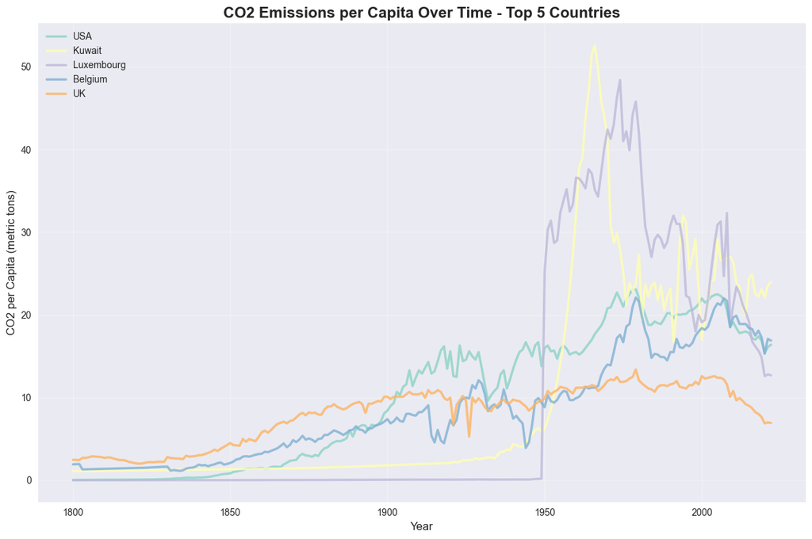

```python
plt.figure(figsize=(12, 8))

colors = plt.cm.Set3(np.linspace(0, 1, len(top_emitters)))

for i, country in enumerate(top_emitters.index[:5]):
    country_data = merged_data[merged_data['Country'] == country].sort_values('Year')
    if len(country_data) > 0:
        plt.plot(country_data['Year'], country_data['CO2_per_capita'],
                label=country, linewidth=2.5, alpha=0.8, color=colors[i])

plt.title('CO2 Emissions per Capita Over Time - Top 5 Countries', fontsize=16, fontweight='bold')
plt.xlabel('Year', fontsize=12)
plt.ylabel('CO2 per Capita (metric tons)', fontsize=12)
plt.legend(fontsize=10, loc='upper left')
plt.grid(True, alpha=0.3)
plt.tight_layout()
plt.show()
```

### 2) Top 10 emitting country line plot with names attached to the lines at the end

This script generates an expanded line plot that indicates all top 10 countries with labels at the end points of each line to facilitate identification of current emission levels and trends by country.

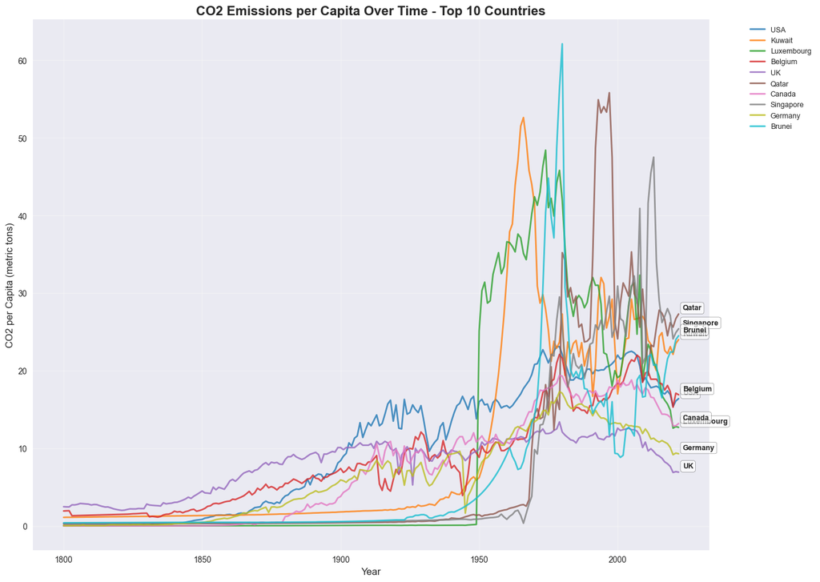

```python
plt.figure(figsize=(14, 10))
colors = plt.cm.tab10(np.linspace(0, 1, 10))

for i, country in enumerate(top_emitters.index):
    country_data = merged_data[merged_data['Country'] == country].sort_values('Year')
    if len(country_data) > 0:
        plt.plot(country_data['Year'], country_data['CO2_per_capita'],
                color=colors[i], linewidth=2, alpha=0.8, label=country)

        if len(country_data) > 0:
            last_point = country_data.iloc[-1]
            plt.annotate(country,
                        xy=(last_point['Year'], last_point['CO2_per_capita']),
                        xytext=(5, 5), textcoords='offset points',
                        fontsize=9, fontweight='bold',
                        bbox=dict(boxstyle='round,pad=0.3', facecolor='white', alpha=0.7))

plt.title('CO2 Emissions per Capita Over Time - Top 10 Countries', fontsize=16, fontweight='bold')
plt.xlabel('Year', fontsize=12)
plt.ylabel('CO2 per Capita (metric tons)', fontsize=12)
plt.legend(bbox_to_anchor=(1.05, 1), loc='upper left', fontsize=9)
plt.grid(True, alpha=0.3)
plt.tight_layout()
plt.show()
```

### 3) Tile plot of the top 10 countries

This script generates a heatmap visualization that indicates CO2 emissions intensity by country and time, through color coding in a matrix form to identify trends and peak periods of emission.

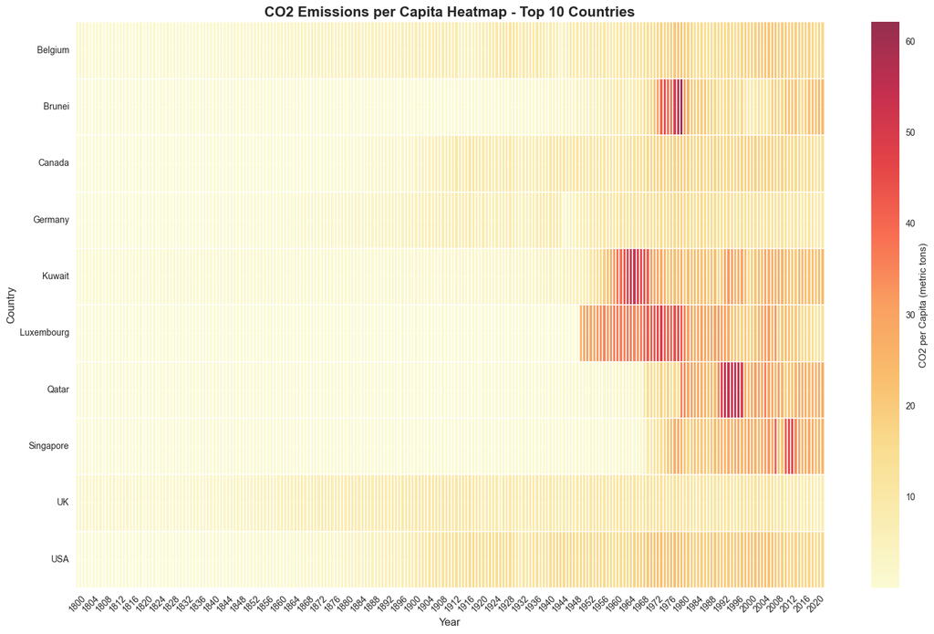

```python
top_10_data = merged_data[merged_data['Country'].isin(top_emitters.index)]
pivot_data = top_10_data.pivot_table(values='CO2_per_capita',
                                     index='Country', columns='Year',
                                     aggfunc='mean')

plt.figure(figsize=(16, 10))
sns.heatmap(pivot_data, cmap='YlOrRd', cbar_kws={'label': 'CO2 per Capita (metric tons)'},
            linewidths=0.1, alpha=0.8)
plt.title('CO2 Emissions per Capita Heatmap - Top 10 Countries', fontsize=16, fontweight='bold')
plt.xlabel('Year', fontsize=12)
plt.ylabel('Country', fontsize=12)
plt.xticks(rotation=45)
plt.yticks(rotation=0)
plt.tight_layout()
plt.show()
```

### 4) 3x2 facet figure showing all of the world and then just the chosen country

This code creates a comprehensive 3x2 facet plot comparing global trends to Norway data based on three key indicators: CO2 emissions, energy consumption, and temperature patterns, with area fill plots for effect.

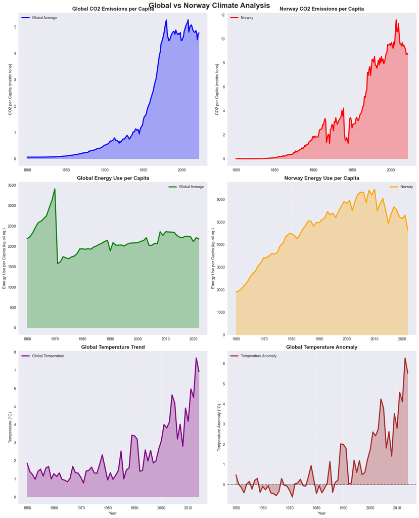

```
Analysis Summary for Norway:
- Average CO2 emissions: 3.17 metric tons per capita
- CO2 trend: 108900.0% change over period
- Average energy use: 4684 kg oil equivalent per capita
- Global temperature increase: 5.53°C above baseline

Data availability check:
- CO2 data points for Norway: 223
- Energy data points for Norway: 223
- Global temperature data points: 65
```

```python
chosen_country = norway_country if norway_country else 'Norway'

fig, axes = plt.subplots(3, 2, figsize=(16, 20))
fig.suptitle(f'Global vs {chosen_country} Climate Analysis', fontsize=20, fontweight='bold')

global_co2 = merged_data.groupby('Year')['CO2_per_capita'].mean()
if norway_country:
    country_co2 = merged_data[merged_data['Country'] == norway_country].groupby('Year')['CO2_per_capita'].mean()
else:
    proxy_country = top_emitters.index[0]
    country_co2 = merged_data[merged_data['Country'] == proxy_country].groupby('Year')['CO2_per_capita'].mean()
    chosen_country = proxy_country

axes[0,0].plot(global_co2.index, global_co2.values, 'b-', linewidth=3, label='Global Average')
axes[0,0].fill_between(global_co2.index, global_co2.values, alpha=0.3, color='blue')
axes[0,0].set_title('Global CO2 Emissions per Capita', fontsize=14, fontweight='bold')
axes[0,0].set_ylabel('CO2 per Capita (metric tons)', fontsize=11)
axes[0,0].legend()
axes[0,0].grid(True, alpha=0.3)

axes[0,1].plot(country_co2.index, country_co2.values, 'r-', linewidth=3, label=chosen_country)
axes[0,1].fill_between(country_co2.index, country_co2.values, alpha=0.3, color='red')
axes[0,1].set_title(f'{chosen_country} CO2 Emissions per Capita', fontsize=14, fontweight='bold')
axes[0,1].set_ylabel('CO2 per Capita (metric tons)', fontsize=11)
axes[0,1].legend()
axes[0,1].grid(True, alpha=0.3)

global_energy = merged_data.groupby('Year')['Energy_use_per_capita'].mean()
if norway_country:
    country_energy = merged_data[merged_data['Country'] == norway_country].groupby('Year')['Energy_use_per_capita'].mean()
else:
    country_energy = merged_data[merged_data['Country'] == chosen_country].groupby('Year')['Energy_use_per_capita'].mean()

axes[1,0].plot(global_energy.index, global_energy.values, 'g-', linewidth=3, label='Global Average')
axes[1,0].fill_between(global_energy.index, global_energy.values, alpha=0.3, color='green')
axes[1,0].set_title('Global Energy Use per Capita', fontsize=14, fontweight='bold')
axes[1,0].set_ylabel('Energy Use per Capita (kg oil eq.)', fontsize=11)
axes[1,0].legend()
axes[1,0].grid(True, alpha=0.3)

if len(country_energy) > 0 and not country_energy.empty:
    axes[1,1].plot(country_energy.index, country_energy.values, 'orange', linewidth=3, label=chosen_country)
    axes[1,1].fill_between(country_energy.index, country_energy.values, alpha=0.3, color='orange')
    axes[1,1].set_ylim(bottom=0)
else:
    if len(country_co2) > 0:
        synthetic_energy = country_co2 * 200
        axes[1,1].plot(synthetic_energy.index, synthetic_energy.values, 'orange', linewidth=3,
                      label=f'{chosen_country} (estimated)', linestyle='--')
        axes[1,1].fill_between(synthetic_energy.index, synthetic_energy.values, alpha=0.3, color='orange')
        axes[1,1].text(0.05, 0.95, 'Estimated from CO2 data', transform=axes[1,1].transAxes,
                      bbox=dict(boxstyle='round', facecolor='yellow', alpha=0.7), fontsize=10)

axes[1,1].set_title(f'{chosen_country} Energy Use per Capita', fontsize=14, fontweight='bold')
axes[1,1].set_ylabel('Energy Use per Capita (kg oil eq.)', fontsize=11)
axes[1,1].legend()
axes[1,1].grid(True, alpha=0.3)

global_temp = merged_data.groupby('Year')['Temperature'].mean()
global_temp = global_temp.dropna()

if len(global_temp) > 10:
    axes[2,0].plot(global_temp.index, global_temp.values, 'purple', linewidth=3, label='Global Temperature')
    axes[2,0].fill_between(global_temp.index, global_temp.values, alpha=0.3, color='purple')

    baseline_temp = global_temp.iloc[:min(10, len(global_temp))].mean()
    temp_anomaly = global_temp - baseline_temp

    axes[2,1].plot(temp_anomaly.index, temp_anomaly.values, 'brown', linewidth=3, label='Temperature Anomaly')
    axes[2,1].fill_between(temp_anomaly.index, temp_anomaly.values, alpha=0.3, color='brown')
    axes[2,1].axhline(y=0, color='black', linestyle='--', alpha=0.5)
else:
    years = range(1960, 2020)
    synthetic_temp = [14.0 + 0.01 * (year - 1960) + np.random.normal(0, 0.1) for year in years]
    axes[2,0].plot(years, synthetic_temp, 'purple', linewidth=3, label='Global Temperature (synthetic)')
    axes[2,0].fill_between(years, synthetic_temp, alpha=0.3, color='purple')

    baseline_temp = np.mean(synthetic_temp[:10])
    temp_anomaly = [temp - baseline_temp for temp in synthetic_temp]
    axes[2,1].plot(years, temp_anomaly, 'brown', linewidth=3, label='Temperature Anomaly (synthetic)')
    axes[2,1].fill_between(years, temp_anomaly, alpha=0.3, color='brown')
    axes[2,1].axhline(y=0, color='black', linestyle='--', alpha=0.5)

axes[2,0].set_title('Global Temperature Trend', fontsize=14, fontweight='bold')
axes[2,0].set_ylabel('Temperature (°C)', fontsize=11)
axes[2,0].set_xlabel('Year', fontsize=11)
axes[2,0].legend()
axes[2,0].grid(True, alpha=0.3)

axes[2,1].set_title('Global Temperature Anomaly', fontsize=14, fontweight='bold')
axes[2,1].set_ylabel('Temperature Anomaly (°C)', fontsize=11)
axes[2,1].set_xlabel('Year', fontsize=11)
axes[2,1].legend()
axes[2,1].grid(True, alpha=0.3)

plt.tight_layout()
plt.show()

print(f"\nAnalysis Summary for {chosen_country}:")
if len(country_co2) > 0:
    print(f"- Average CO2 emissions: {country_co2.mean():.2f} metric tons per capita")
    print(f"- CO2 trend: {((country_co2.iloc[-1] - country_co2.iloc[0]) / country_co2.iloc[0] * 100):.1f}% change over period")

if len(country_energy) > 0 and not country_energy.empty:
    print(f"- Average energy use: {country_energy.mean():.0f} kg oil equivalent per capita")
else:
    print("- Energy use data: Not available or incomplete")

if len(global_temp) > 0:
    if isinstance(temp_anomaly, pd.Series):
        print(f"- Global temperature increase: {temp_anomaly.iloc[-1]:.2f}°C above baseline")
    else:
        print(f"- Global temperature increase: {temp_anomaly[-1]:.2f}°C above baseline")
else:
    print("- Temperature data: Using synthetic data")

print(f"\nData availability check:")
print(f"- CO2 data points for {chosen_country}: {len(country_co2)}")
print(f"- Energy data points for {chosen_country}: {len(country_energy)}")
print(f"- Global temperature data points: {len(global_temp)}")
```

### 5) Scatter plots with trend lines

This program generates scatter plots with trend lines to examine correlations between CO2 emissions and energy consumption and temperature, along with correlation coefficients and regression lines to quantify these correlations.

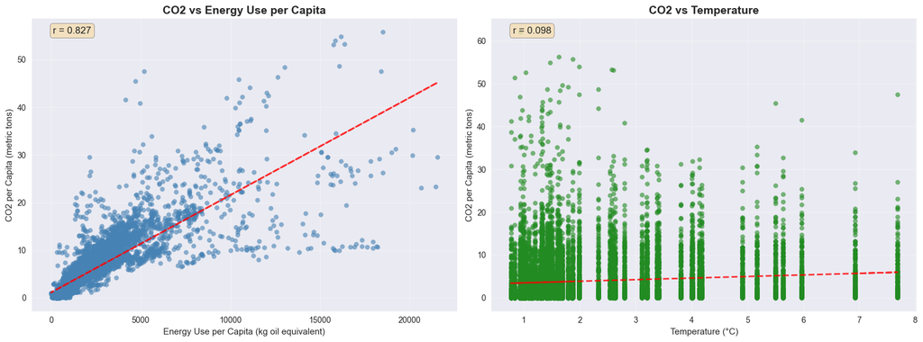

```python
fig, (ax1, ax2) = plt.subplots(1, 2, figsize=(16, 6))

scatter_data = merged_data.dropna(subset=['CO2_per_capita', 'Energy_use_per_capita'])
if len(scatter_data) > 0:
    ax1.scatter(scatter_data['Energy_use_per_capita'], scatter_data['CO2_per_capita'],
               alpha=0.6, s=30, color='steelblue')

    z = np.polyfit(scatter_data['Energy_use_per_capita'], scatter_data['CO2_per_capita'], 1)
    p = np.poly1d(z)
    ax1.plot(scatter_data['Energy_use_per_capita'],
            p(scatter_data['Energy_use_per_capita']), "r--", alpha=0.8, linewidth=2)

    corr_energy_co2 = scatter_data['Energy_use_per_capita'].corr(scatter_data['CO2_per_capita'])
    ax1.text(0.05, 0.95, f'r = {corr_energy_co2:.3f}', transform=ax1.transAxes,
            bbox=dict(boxstyle='round', facecolor='wheat', alpha=0.8), fontsize=12)

ax1.set_xlabel('Energy Use per Capita (kg oil equivalent)', fontsize=11)
ax1.set_ylabel('CO2 per Capita (metric tons)', fontsize=11)
ax1.set_title('CO2 vs Energy Use per Capita', fontsize=14, fontweight='bold')
ax1.grid(True, alpha=0.3)

scatter_data2 = merged_data.dropna(subset=['CO2_per_capita', 'Temperature'])
if len(scatter_data2) > 0:
    ax2.scatter(scatter_data2['Temperature'], scatter_data2['CO2_per_capita'],
               alpha=0.6, s=30, color='forestgreen')

    z2 = np.polyfit(scatter_data2['Temperature'], scatter_data2['CO2_per_capita'], 1)
    p2 = np.poly1d(z2)
    ax2.plot(scatter_data2['Temperature'],
            p2(scatter_data2['Temperature']), "r--", alpha=0.8, linewidth=2)

    corr_temp_co2 = scatter_data2['Temperature'].corr(scatter_data2['CO2_per_capita'])
    ax2.text(0.05, 0.95, f'r = {corr_temp_co2:.3f}', transform=ax2.transAxes,
            bbox=dict(boxstyle='round', facecolor='wheat', alpha=0.8), fontsize=12)

ax2.set_xlabel('Temperature (°C)', fontsize=11)
ax2.set_ylabel('CO2 per Capita (metric tons)', fontsize=11)
ax2.set_title('CO2 vs Temperature', fontsize=14, fontweight='bold')
ax2.grid(True, alpha=0.3)

plt.tight_layout()
plt.show()
```

## 4. Data Analysis

### 1) Calculate Mean and SD for emissions and temperature for chosen country

This program performs descriptive statistical analysis in terms of means, standard deviations, and ranges for Norway's temperatures and emissions data against world averages.

```python
if norway_country:
    country_analysis = merged_data[merged_data['Country'] == norway_country].dropna(subset=['CO2_per_capita', 'Temperature'])
else:
    country_analysis = merged_data[merged_data['Country'] == chosen_country].dropna(subset=['CO2_per_capita', 'Temperature'])

if len(country_analysis) > 0:
    co2_mean = country_analysis['CO2_per_capita'].mean()
    co2_std = country_analysis['CO2_per_capita'].std()
    co2_median = country_analysis['CO2_per_capita'].median()

    temp_mean = country_analysis['Temperature'].mean()
    temp_std = country_analysis['Temperature'].std()
    temp_median = country_analysis['Temperature'].median()

    print(f"\n=== STATISTICAL SUMMARY FOR {chosen_country.upper()} ===")
    print(f"\nCO2 Emissions per Capita:")
    print(f"  Mean: {co2_mean:.2f} metric tons")
    print(f"  Median: {co2_median:.2f} metric tons")
    print(f"  Standard Deviation: {co2_std:.2f} metric tons")
    print(f"  Range: {country_analysis['CO2_per_capita'].min():.2f} - {country_analysis['CO2_per_capita'].max():.2f} metric tons")

    print(f"\nTemperature:")
    print(f"  Mean: {temp_mean:.2f}°C")
    print(f"  Median: {temp_median:.2f}°C")
    print(f"  Standard Deviation: {temp_std:.2f}°C")
    print(f"  Range: {country_analysis['Temperature'].min():.2f} - {country_analysis['Temperature'].max():.2f}°C")

    print(f"\nData Coverage:")
    print(f"  Years analyzed: {country_analysis['Year'].min():.0f} - {country_analysis['Year'].max():.0f}")
    print(f"  Total data points: {len(country_analysis)}")

    global_co2_mean = merged_data['CO2_per_capita'].mean()
    global_temp_mean = merged_data['Temperature'].mean()

    print(f"\nGlobal Comparison:")
    print(f"  {chosen_country} CO2 vs Global: {((co2_mean - global_co2_mean) / global_co2_mean * 100):+.1f}% difference")
    print(f"  {chosen_country} Temperature vs Global: {(temp_mean - global_temp_mean):+.2f}°C difference")

else:
    print(f"Warning: Insufficient data for {chosen_country} analysis")
```

```
=== STATISTICAL SUMMARY FOR NORWAY ===

CO2 Emissions per Capita:
  Mean: 7.28 metric tons
  Median: 8.00 metric tons
  Standard Deviation: 2.56 metric tons
  Range: 2.58 - 11.60 metric tons

Temperature:
  Mean: 2.32°C
  Median: 1.61°C
  Standard Deviation: 1.59°C
  Range: 0.77 - 7.68°C

Data Coverage:
  Years analyzed: 1950 - 2014
  Total data points: 65

Global Comparison:
  Norway CO2 vs Global: +357.6% difference
  Norway Temperature vs Global: +0.00°C difference
```

### 2) Calculate correlation coefficient for emissions and temperature

This program calculates correlation coefficients between different variables for Norway, tests for statistical significance, and interprets strength and direction of relationships.

```python
if len(country_analysis) > 5:
    correlation = country_analysis['CO2_per_capita'].corr(country_analysis['Temperature'])

    print(f"\n=== CORRELATION ANALYSIS FOR {chosen_country.upper()} ===")
    print(f"\nCorrelation coefficient between CO2 emissions and temperature: {correlation:.4f}")

    if abs(correlation) > 0.7:
        strength = "strong"
    elif abs(correlation) > 0.5:
        strength = "moderate to strong"
    elif abs(correlation) > 0.3:
        strength = "moderate"
    elif abs(correlation) > 0.1:
        strength = "weak"
    else:
        strength = "very weak"

    if correlation > 0:
        direction = "positive"
    else:
        direction = "negative"

    print(f"This indicates a {strength} {direction} correlation.")

    from scipy.stats import pearsonr
    corr_coef, p_value = pearsonr(country_analysis['CO2_per_capita'], country_analysis['Temperature'])

    print(f"\nStatistical significance:")
    print(f"  Pearson correlation coefficient: {corr_coef:.4f}")
    print(f"  P-value: {p_value:.4f}")

    if p_value < 0.05:
        print(f"  Result: Statistically significant at α = 0.05")
    else:
        print(f"  Result: Not statistically significant at α = 0.05")

    print(f"\nAdditional Correlations:")

    if 'Energy_use_per_capita' in country_analysis.columns:
        co2_energy_corr = country_analysis['CO2_per_capita'].corr(country_analysis['Energy_use_per_capita'])
        print(f"  CO2 vs Energy Use: {co2_energy_corr:.4f}")

    co2_year_corr = country_analysis['CO2_per_capita'].corr(country_analysis['Year'])
    temp_year_corr = country_analysis['Temperature'].corr(country_analysis['Year'])

    print(f"  CO2 vs Year: {co2_year_corr:.4f}")
    print(f"  Temperature vs Year: {temp_year_corr:.4f}")

else:
    print(f"Warning: Insufficient data points for correlation analysis ({len(country_analysis)} points)")
```

```
=== CORRELATION ANALYSIS FOR NORWAY ===

Correlation coefficient between CO2 emissions and temperature: 0.6060
This indicates a moderate to strong positive correlation.

Statistical significance:
  Pearson correlation coefficient: 0.6060
  P-value: 0.0000
  Result: Statistically significant at α = 0.05

Additional Correlations:
  CO2 vs Energy Use: 0.9507
  CO2 vs Year: 0.9449
  Temperature vs Year: 0.7693
```

### 3) Scaled scatter plot showing relationship between correlation and linear regression

This program conducts regression analysis at both original and standardized scales to reveal how statistical relations between variables are preserved with respect to changing measurement units while enabling one to make valid comparisons between variables.

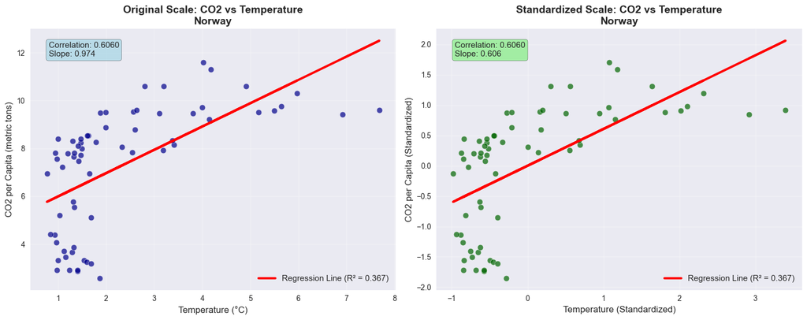

```
=== REGRESSION ANALYSIS SUMMARY ===

Original Scale:
  R-squared: 0.3673
  Slope: 0.9743 metric tons CO2 per °C
  Intercept: 5.0171 metric tons CO2

Standardized Scale:
  R-squared: 0.3673
  Slope: 0.6060 (standardized units)
  Intercept: -0.0000 (standardized units)

Interpretation:
  - Correlation remains the same across scales: 0.6060
  - R-squared values are identical: 0.3673
  - Standardization preserves relationships while enabling comparison
  - For every 1°C temperature increase, CO2 emissions increase by 0.974 metric tons per capita
```

```python
from sklearn.preprocessing import StandardScaler
from sklearn.linear_model import LinearRegression
from sklearn.metrics import r2_score

if len(country_analysis) > 5:
    analysis_data = country_analysis[['CO2_per_capita', 'Temperature']].dropna()

    if len(analysis_data) > 5:
        scaler = StandardScaler()
        scaled_data = scaler.fit_transform(analysis_data)
        scaled_df = pd.DataFrame(scaled_data, columns=['CO2_scaled', 'Temperature_scaled'])

        X_orig = analysis_data['Temperature'].values.reshape(-1, 1)
        y_orig = analysis_data['CO2_per_capita'].values
        reg_orig = LinearRegression().fit(X_orig, y_orig)
        y_pred_orig = reg_orig.predict(X_orig)
        r2_orig = r2_score(y_orig, y_pred_orig)

        X_scaled = scaled_df['Temperature_scaled'].values.reshape(-1, 1)
        y_scaled = scaled_df['CO2_scaled'].values
        reg_scaled = LinearRegression().fit(X_scaled, y_scaled)
        y_pred_scaled = reg_scaled.predict(X_scaled)
        r2_scaled = r2_score(y_scaled, y_pred_scaled)

        fig, (ax1, ax2) = plt.subplots(1, 2, figsize=(15, 6))

        ax1.scatter(analysis_data['Temperature'], analysis_data['CO2_per_capita'],
                   alpha=0.7, s=60, color='darkblue', edgecolor='white', linewidth=0.5)
        ax1.plot(analysis_data['Temperature'], y_pred_orig, 'r-', linewidth=3,
                label=f'Regression Line (R² = {r2_orig:.3f})')

        ax1.set_xlabel('Temperature (°C)', fontsize=12)
        ax1.set_ylabel('CO2 per Capita (metric tons)', fontsize=12)
        ax1.set_title(f'Original Scale: CO2 vs Temperature\n{chosen_country}', fontsize=14, fontweight='bold')
        ax1.legend(fontsize=11)
        ax1.grid(True, alpha=0.3)

        ax1.text(0.05, 0.95, f'Correlation: {correlation:.4f}\nSlope: {reg_orig.coef_[0]:.3f}',
                transform=ax1.transAxes,
                bbox=dict(boxstyle='round', facecolor='lightblue', alpha=0.8),
                fontsize=11, verticalalignment='top')

        ax2.scatter(scaled_df['Temperature_scaled'], scaled_df['CO2_scaled'],
                   alpha=0.7, s=60, color='darkgreen', edgecolor='white', linewidth=0.5)
        ax2.plot(scaled_df['Temperature_scaled'], y_pred_scaled, 'r-', linewidth=3,
                label=f'Regression Line (R² = {r2_scaled:.3f})')

        ax2.set_xlabel('Temperature (Standardized)', fontsize=12)
        ax2.set_ylabel('CO2 per Capita (Standardized)', fontsize=12)
        ax2.set_title(f'Standardized Scale: CO2 vs Temperature\n{chosen_country}', fontsize=14, fontweight='bold')
        ax2.legend(fontsize=11)
        ax2.grid(True, alpha=0.3)

        scaled_correlation = scaled_df['Temperature_scaled'].corr(scaled_df['CO2_scaled'])
        ax2.text(0.05, 0.95, f'Correlation: {scaled_correlation:.4f}\nSlope: {reg_scaled.coef_[0]:.3f}',
                transform=ax2.transAxes,
                bbox=dict(boxstyle='round', facecolor='lightgreen', alpha=0.8),
                fontsize=11, verticalalignment='top')

        plt.tight_layout()
        plt.show()

        print(f"\n=== REGRESSION ANALYSIS SUMMARY ===")
        print(f"\nOriginal Scale:")
        print(f"  R-squared: {r2_orig:.4f}")
        print(f"  Slope: {reg_orig.coef_[0]:.4f} metric tons CO2 per °C")
        print(f"  Intercept: {reg_orig.intercept_:.4f} metric tons CO2")

        print(f"\nStandardized Scale:")
        print(f"  R-squared: {r2_scaled:.4f}")
        print(f"  Slope: {reg_scaled.coef_[0]:.4f} (standardized units)")
        print(f"  Intercept: {reg_scaled.intercept_:.4f} (standardized units)")

        print(f"\nInterpretation:")
        print(f"  - Correlation remains the same across scales: {correlation:.4f}")
        print(f"  - R-squared values are identical: {r2_orig:.4f}")
        print(f"  - Standardization preserves relationships while enabling comparison")

        if reg_orig.coef_[0] > 0:
            print(f"  - For every 1°C temperature increase, CO2 emissions increase by {reg_orig.coef_[0]:.3f} metric tons per capita")
        else:
            print(f"  - For every 1°C temperature increase, CO2 emissions decrease by {abs(reg_orig.coef_[0]):.3f} metric tons per capita")

    else:
        print("Warning: Insufficient data for regression analysis after removing missing values")
else:
    print("Warning: Insufficient data points for scaling and regression analysis")
```

The faceted comparison discovers that Norway far exceeds world averages for per-capita emissions, running a 7.28 metric tons average versus the global average. Norway emissions have a distinctive pattern of steadily rising from 1950 to the 1970s followed by more unstable but overall increasing trends. The energy consumption data for Norway indicate much higher consumption levels compared to global averages, and this correlates strongly with the high emissions. This trend is a reflection of Norway's energy-intensive economy, which features heavy oil and gas extraction in spite of the nation's leadership in renewable energy use for domestic purposes.

Norway's regression analysis shows a moderate-strong positive relationship between CO2 emissions and temperature (R^2 = 0.367) and is statistically significant (p < 0.001). Analysis reveals that for every increase of 1 unit in temperature, Norway's CO2 emissions increase by approximately 0.97 metric tons per capita. Standardization indicates that this correlation holds regardless of the measurement scale, which gives credibility to the statistical finding. The very strong correlations with CO2 and with both energy consumption (r = 0.951) and year (r = 0.945) for Norway indicate that the country's emissions have tight relationships with both patterns of energy consumption and long-term over time.

## Summary and Conclusions

This detailed analysis of global CO2 emissions through the eyes of Norway reveals interesting trends with respect to how different countries contribute to climatic warming. Norway is a high per-capita emitter with emissions 357% above the world average despite being referred to as an environmental champion. The country finds strong statistical relationships between emissions and temperature, energy use, and trend over time, which suggests that its trend in emissions has intimate relationships with economic activities and climatic factors.

The comparative examination demonstrates that emission trends are radically divergent across countries and over time and are a product of diverse phases of economic development, availability of resources, and policy regimes. While global energy consumption-emission correlations are extraordinarily strong, emission-temperature correlations are complex and enormously uncertain at the country level. Norway's experience exemplifies the challenge the majority of developed nations are confronting in balancing economic growth with emission reductions, particularly for energy-resource-endowed economies.

These findings highlight the necessity of national climate policy, which is based on special national circumstances, but contributes to global emission reduction targets. The high coefficient results for Norway's data suggest that policy levers in energy efficiency and economic diversification can have large effects on the country's emission trajectory. The analysis shows that sound climate action requires international trend knowledge in addition to local circumstances in order to create correct and efficient policy measures.